# Loading and preprocessing the data

## Loading and preprocessing the data

```r
unzip("activity.zip")
activity_data <- read.csv("activity.csv", header = T,
                          colClasses = c("integer", "character", "integer"))
Date <- strptime(activity_data$date,"%Y-%m-%d")
activity_data <- cbind(activity_data, Date)
```

## What is mean total number of steps taken per day?

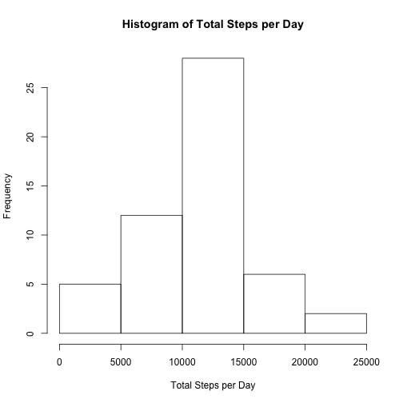

```r
total_steps_per_day <- aggregate(steps ~ Date, data = activity_data, sum)
hist(total_steps_per_day$steps, xlab = "Total Steps per Day",
     main = "Histogram of Total Steps per Day")
```

```r
mean_steps_per_day <- mean(total_steps_per_day$steps)
median_steps_per_day <- median(total_steps_per_day$steps)
```

Mean total number of steps taken per day: 1.0766189 × 10<sup>4</sup>  
Median total number of steps taken per day: 10765

## What is the average daily activity pattern?

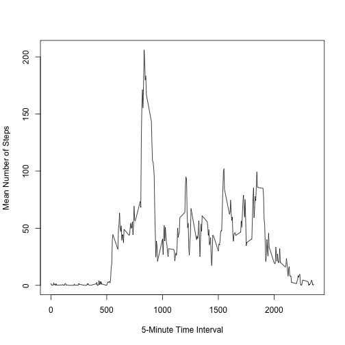

```r
mean_steps_per_interval <- aggregate(steps ~ interval, data = activity_data,
                                     mean)
colnames(mean_steps_per_interval) <- c("interval", "mean_steps")
with(mean_steps_per_interval, plot(interval, mean_steps, type="l",
                                   ylab = "Mean Number of Steps",
                                   xlab = "5-Minute Time Interval"))
```

```r
max_steps_interval <-
    mean_steps_per_interval[which.max(mean_steps_per_interval$mean_steps),1]
```

5-Minute Time Interval with Most Steps: 835

## Imputing missing values

```r
num_na_rows <- nrow(activity_data) - sum(complete.cases(activity_data))
```

Number of rows with NA values: 2304

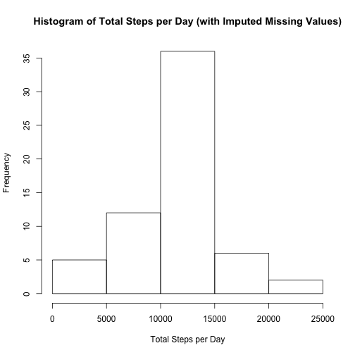

```r
# Use the mean_steps_interval data frame generated earlier to replace any
# missing step values with the mean for that 5-minute interval
new_activity_data <- merge(x = activity_data, y = mean_steps_per_interval,
                           by = "interval")
new_activity_data$steps[is.na(new_activity_data$steps)] <-
    new_activity_data$mean_steps[is.na(new_activity_data$steps)]

new_total_steps_per_day <- aggregate(steps ~ Date, data = new_activity_data,
                                     sum)
hist(new_total_steps_per_day$steps,
     xlab = "Total Steps per Day",
     main = "Histogram of Total Steps per Day (with Imputed Missing Values)")
```

```r
new_mean_steps_per_day <- mean(new_total_steps_per_day$steps)
new_median_steps_per_day <- median(new_total_steps_per_day$steps)
```

Mean total number of steps taken per day (with imputed missing values): 1.0766189 × 10<sup>4</sup>  
Median total number of steps taken per day (with imputed missing values): 1.0766189 × 10<sup>4</sup>

It would appear that imputing the missing step values with the mean of the corresponding 5-minute interval does not change the mean in any way. However, the median is no longer 10765, but now 10766.19 which is to be expected. In the original data set, there are a few days that have no step values recorded at all. When all the step values for these days are replaced with their corresponding intervals, their total will add up to the mean of 10766.19 which now also becomes the new median since it is also the center of the data.

## Are there differences in activity patterns between weekdays and weekends?

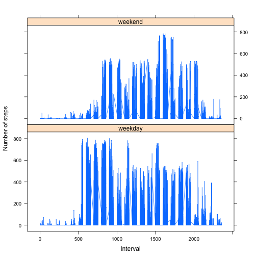

```r
day_names <- weekdays(new_activity_data$Date)
day_names[day_names %in% c("Sunday", "Saturday")] <- "weekend"
day_names[day_names != "weekend"] <- "weekday"
day_type <- day_names
new_activity_data <- cbind(new_activity_data, day_type)

library(lattice)
xyplot(steps ~ interval | day_type, data = new_activity_data,
       ylab = "Number of steps", xlab = "Interval",
       layout=c(1,2), type = "l")
```